# Lecture Notes - Week 1

What is Statistical Learning?

2023-06-18

# Three graphs as starter

[figure not shown]

Source: Wage data, which contains income survey information for men from the central Atlantic region of the United States (ISLR book, page 2)

# ABC of Statistical Learning

Statistical learning refers to a set of tools for making sense of complex datasets.

- Our aim is to **get knowledge** from the set of **data** with a **suitable model**
- For this goal, we need a **certain level** of programming language skills, in our case, **R-language**.

# More Details

- Statistical learning refers to a **vast set of tools** for understanding data.
- Sometimes you can heard it as a **part of machine learning** nowadays.
- Different learning methods (**supervised or unsupervised**, *prediction or classification*)
- **Supervised**;
  - building a statistical model for predicting, or estimating, an output based on one or more inputs
- **Unsupervised**;
  - there are inputs but no supervising output; nevertheless we can learn relationships and structure from such data

# Brief History

- Though the term statistical learning is fairly new, many of the concepts that underlie the field were developed long ago.
- At the beginning of the nineteenth century, the method of least squares was developed, implementing the earliest form of what is now known as linear regression, first applied for problems in astronomy.
- In order to predict qualitative values, such as whether a patient survives or dies, or whether the stock market increases or decreases, linear discriminant analysis was proposed in 1936.
- In the 1940s, various authors put forth an alternative approach, logistic regression.
- In the early 1970s, the term generalized linear model was developed to describe an entire class of statistical learning methods that include both linear and logistic regression as special cases

# Brief History

- By the end of the 1970s, many more techniques for learning from data were available
- the 1980s, computing technology had finally improved sufficiently that non-linear methods were no longer computationally prohibitive
- In the mid 1980s, classification and regression trees were developed, followed shortly by generalized additive models
- Neural networks gained popularity in the 1980s, and support vector machines arose in the 1990s

# Why do we need ?

- Many statistical learning methods are relevant and useful in a wide range of academic and non-academic disciplines, beyond just the statistical sciences.
- Statistical learning should not be viewed as a series of black boxes. No single approach will perform well in all possible applications.
- In our course, aim is understanding the steps to describe the model, intuition, assumptions, and trade-offs behind each of the methods that we consider
- The course is intended for anyone who is interested in using modern statistical methods to extract the information from available data.

# Key important concepts

- Type of variables
- Supervised / Unsupervised learning
- Prediction / classification method
- Parametric versus Non-parametric
- Prediction Accuracy versus Model Interpretability
- bias-variance trade-off (overfitting / underfitting problem)

# Type of variables

[figure not shown]

Source: http://www.intellspot.com/data-types/

# Quantitative versus Qualitative

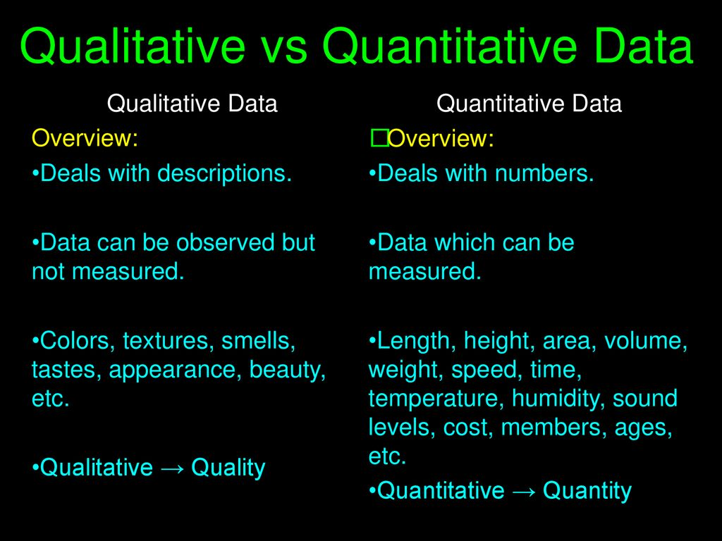

Source: https://slideplayer.com/slide/14728003/

# Supervised versus Unsupervised

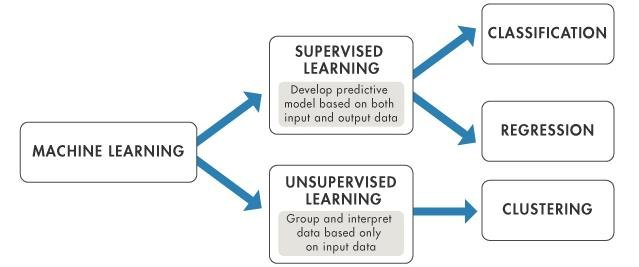

Source: https://www.researchgate.net/publication/319937079_A_Machine_Learning_Framework_for_Sport_Result_Prediction

# Supervised versus Unsupervised

Most statistical learning problems fall into one of two categories:

- Supervised: For each observation of the predictor measurement(s) $x_i$, for $i = 1, \ldots, n$ there is an associated response measurement $y_i$.
  - We wish to fit a model that relates the response to the predictors, with the aim of accurately predicting the response for future observations (prediction) or better understanding the relationship between the response and the predictors (inference)
- Unsupervised: For each observation of the predictor measurement(s) $x_i$, for $i = 1, \ldots, n$, but there is NO associated response value $y_i$.
  - working blind; the situation is referred to as unsupervised because we lack a response variable that can supervise our analysis

# Supervised versus Unsupervised

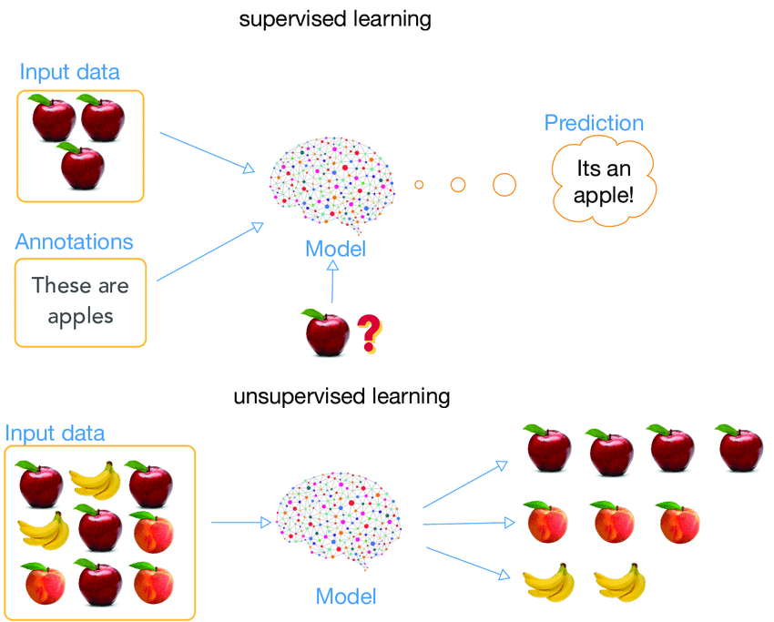

Source: https://www.researchgate.net/publication/329533120_Background_Augmentation_Generative_Adversarial_Networks_BAGANs_Effective_Data_Generation_Based_on_GAN-Augmented_3D_Synthesizing/figures?lo=1

# Supervised versus Unsupervised

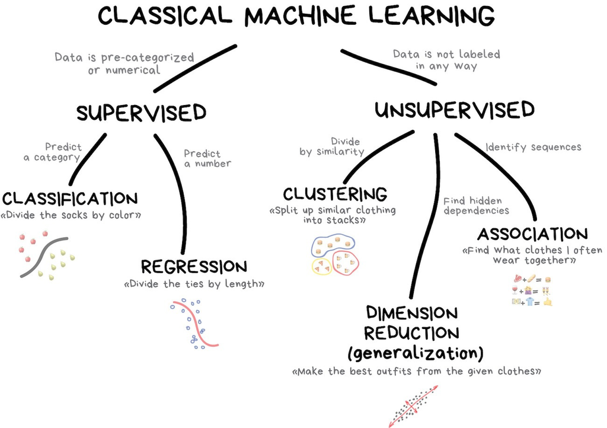

Source: https://github.com/iammiori/data_analysis_python/issues/1

# Prediction versus Classification

Previously, we have seen the main types of variables as; i) quantitative or ii) qualitative (or categorical).

- Quantitative variables take on numerical values.
  - a person’s age
  - height
  - the value of a house
- Qualitative variables take on values in one of K different classes, or categories
  - person’s marital status
  - the brand of a product
  - cancer diagnosis

The distinction is not always that crisp. Be careful about it !

**We tend to select statistical learning methods on the basis of whether the response is quantitative or qualitative. Whether the predictors are qualitative or quantitative is generally considered less important**

# Prediction versus Classification

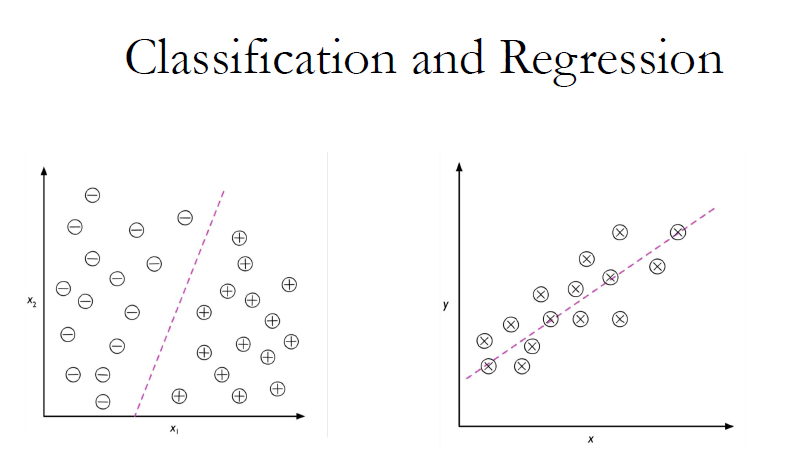

Source: Yasin Ceran, Machine Learning Tutorial, Week1-Part 1, Introduction.

# Terminology Summary

Basically, Predictive modeling can be defined as the process of uncovering relationships within data for predicting some desired outcome, over the below mentioned terms;

- **Sample, data point, observation, or instance** refer to a single, independent unit of data, such as a customer, patient, or compound. The term **sample** can also refer to a subset of data points, such as the training set sample.
- The **training set** consists of the data used to develop models while the **test or validation sets** are used solely for evaluating the performance of a final set of candidate models
- The **predictors**, **independent variables**, **attributes**, or **descriptors** are the data used as input for the prediction equation
- **Outcome**, **dependent variable**, **target**, **class**, or **response** refer to the outcome event or quantity that is being predicted
- **Continuous data** have natural, numeric scales. Blood pressure, the cost of an item, or the number of bathrooms are all continuous. In the last case, the counts cannot be a fractional number, but is still treated as continuous data
- **Categorical data**, otherwise known as **nominal**, **attribute**, or **discrete data**, take on specific values that have no scale. Credit status (“good” or “bad”) or color (“red,”“blue,” etc.) are examples of these data
- **Model building**, **model training**, and **parameter estimation** all refer to the process of using data to determine values of model equations

Reading: 1.4 Example Data Sets and Typical Data Scenarios from the book of Applied Predictivel Modeling (Kuhn and Johnson)

# A simple case

Imagine; you are statistical consultants hired by a company to investigate the relationship between advertising and sales of a particular product.

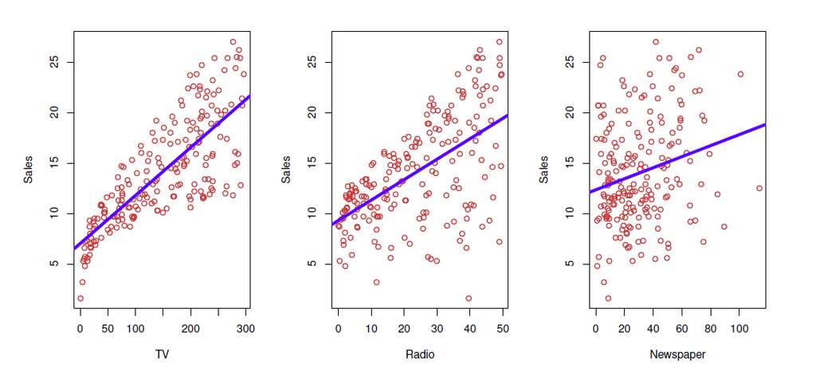

Source: FIGURE 2.1 (ISLR book, page 16)

GOAL: To develop an accurate model to predict sales on the basis of the three media budgets

# Basic Notation

Generally speaking, by using input variables, we want to get information about the output variable.

$Y$ is the quantitative response variable (sales) with $p$ different predictors $\mathbf{X} = (X_1, \ldots, X_p)$. Assume that the following relationship;

$$Y = f(\mathbf{X}) + \epsilon$$
where $f$ is the fixed / unknown function of $\mathbf{X}$ and $\epsilon$ is the random error having the properties;

- independent from $\mathbf{X}$
- has mean zero ($E[\epsilon] = \mu_{\epsilon} = 0$).

AIM: Estimate of $f$ to get the systematic information of $\mathbf{X}$ gives about $Y$.

NOTE: Statistical learning refers to a set of approaches for estimating $f$

# Why Estimate f?

There are two main reasons that we may wish to estimate

- Prediction
- Inference

# Prediction

- a set of inputs X are readily available, but the output Y cannot be easily obtained.
- since the error term averages to zero, $\widehat{Y} = \widehat{f}(X)$
- The accuracy of $\widehat{Y}$ depends on two quantities; the *reducible error* and the *irreducible error*.

Consider a given estimate $\widehat{f}$ and a set of predictors $X$, which yields the prediction $\widehat{Y} = \widehat{f}(X)$ for the true value $Y$.

$E[Y-\widehat{Y}]^2 = E[f(X) + \epsilon - \widehat{f}(X)]^2 \\ = [f(X) - \widehat{f}(X)]^2 + Var(\epsilon)$

where $E[Y-\widehat{Y}]^2$ is the average or expected value of the squared distance between the prediction and true value, $Var(\epsilon)$ is the variance tied to the irreducible error term.

# Inference

- Instead of getting the unknown value of the response, we can interested in understanding the association between $Y$ and $X_{1:p}$.
- We wish to estimate f, but our goal is not necessarily to make predictions for Y
- One can be interested in followings;
  - Which predictors are associated with the response?
  - What is the relationship between the response and each predictor?
  - Can the relationship between Y and each predictor be adequately summarized using a linear equation, or is the relationship more complicated?

Example: the Advertising data illustrated in Figure 2.1

**REMARK: Depending on whether our ultimate goal is prediction, inference, or a combination of the two, different methods for estimating f may be appropriate**

# How Estimate f ?

Many linear and non-linear approaches for estimating f but these methods share certain characteristics;

- The we have observed a set of $n$ different data points
- These observations are called the training data because we will use these to train, or teach, our model to estimate f

Let $(y_i, x_{i,j})$ be the set of response variable and its predictors. Here, $x_{i,j}$ is the value of the $j$’th predictor (input), for observation $i$ withe the corresponding response $y_i$.

- In other words, find a function $\widehat{f}$ such that $Y \approx \widehat{f}$ for any observation of $(X, Y)$.
- Most statistical learning methods for this task can be characterized as either parametric or non-parametric

# Parametric versus Non-parametric

Parametric methods involve a two-step model-based approach;

- First make an assumption about the functional form of $f$. To illustrate,

linear case $f(X) = \beta_0 + \beta_1 X_1 \hspace{1cm} (1)$ $f(X) = \beta_0 + \beta_1 X_1 + \ldots + \beta_p X_p \hspace{1cm} (2)$

non-linear case $f(X) = \beta_0 + \beta_1 X_1 + \ldots + \beta_p X_p + \beta_{11} X_1^2 \hspace{1cm} (3)$

When we decide the structure of f, the problem of estimating is greatly simplified.

1. Instead of having to estimate an entirely arbitrary function $f(X)$, one only needs to estimate the pre-defined parameters.

To illustrate, one only needs to estimate the $p+1$ coefficients $\beta_0, \ldots, \beta_p$ in $(2)$

2. After a model has been selected, we need a procedure that uses the training data to fit or train the model. Equivalently, find the values of parameters in $(2)$ s.t

$Y \approx \beta_0 + \beta_1 X_1 + \ldots + \beta_p X_p$

# Parametric versus Non-parametric

Non-parametric methods do not make explicit assumptions about the functional form of $f$ at the beginning.

- they seek an estimate of f that gets as close to the data points as possible without being too rough or wiggly.
- Such approaches can have a major advantage over parametric approaches: by avoiding the assumption of a particular functional form for f, they have the potential to accurately fit a wider range of possible shapes for f
- But non-parametric approaches do suffer from a major disadvantage:
  - since they do not reduce the problem of estimating f to a small number of parameters, a very large number of observations (far more than is typically needed for a parametric approach) is required in order to obtain an accurate estimate for $f$.

REMARK: there are advantages and disadvantages to parametric and non-parametric methods for statistical learning. We explore both types of methods

# Prediction Accuracy versus Model Interpretability

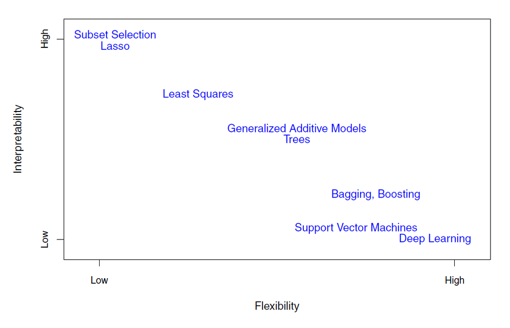

Source: FIGURE 2.7 (ISLR book, page 25)

- When inference is the goal, there are clear advantages to using simple and relatively inflexible statistical learning methods.
- however, we are only interested in prediction, and the interpretability of the predictive model is simply not of interest.

# Training versus Testing sets

we need to use observations that aren’t used in the training process. Otherwise, the evaluation of the model would be biased.

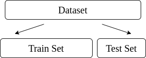

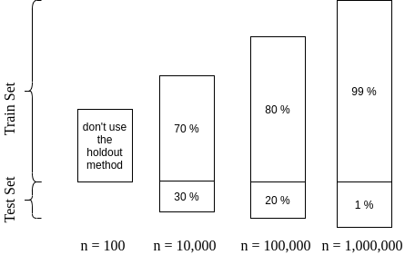

80:20 is a good starting point but we need to make sure that the test set represents most of the variance in the dataset

Source: https://www.baeldung.com/cs/train-test-datasets-ratio

# Model Accuracy Assessment

Why is it necessary to introduce so many different statistical learning approaches, rather than just a single best method?

- no one method dominates all others over all possible data sets
- “all models are wrong, but some are useful” (G. Box)
- Selecting the best model be one of the most challenging parts of performing statistical learning

So one needs a measure to compare the performance of various models

# Measuring the Quality of Fit

In the regression setting, the most commonly-used measure is the mean squared error (MSE)

$MSE = \frac{1}{n} \sum_{i = 1}^{n} (y_i - \widehat{f}(x_i))^2$

What is the interpretation ?

# What else ?

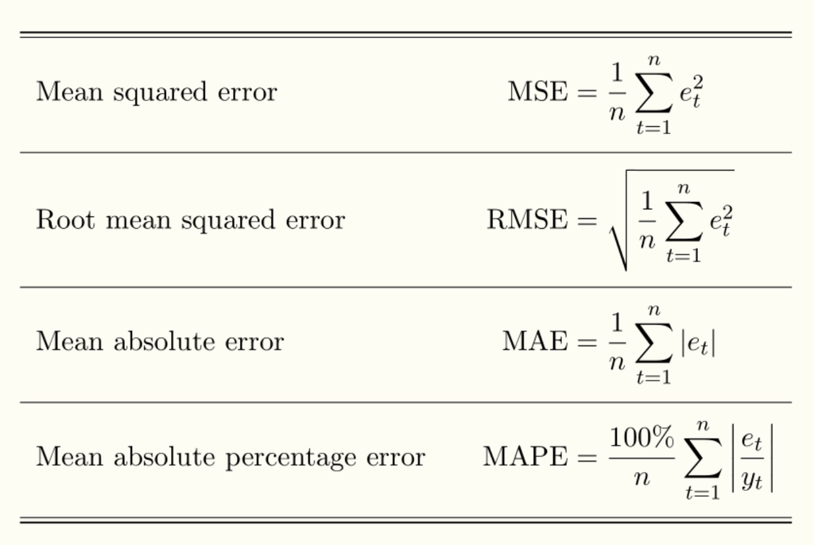

Source: https://medium.com/acing-ai/how-to-evaluate-regression-models-d183b4f5853d

# Overfitting versus Underfitting

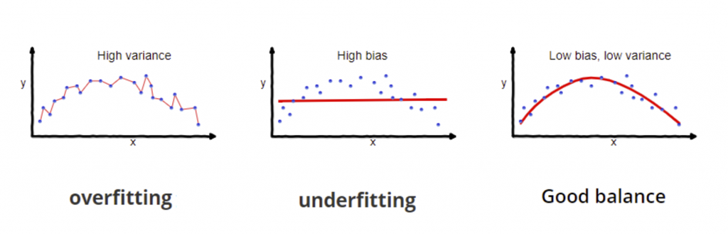

Source: https://andreaprovino.it/bias-variance-tradeoff/

# Overfitting versus Underfitting

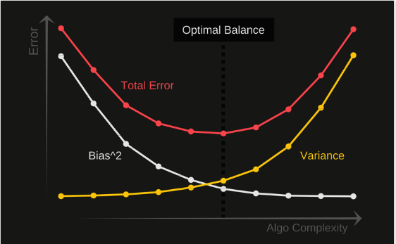

Source: https://andreaprovino.it/bias-variance-tradeoff/

# The bias-variance trade-off

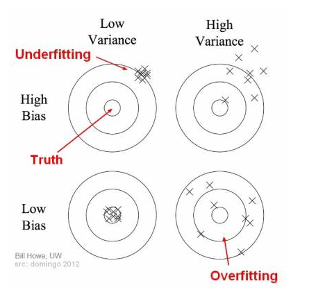

Source: https://medium.com/@toprak.mhmt/the-bias-variance-tradeoff-d9320282ac04

# The bias-variance trade-off

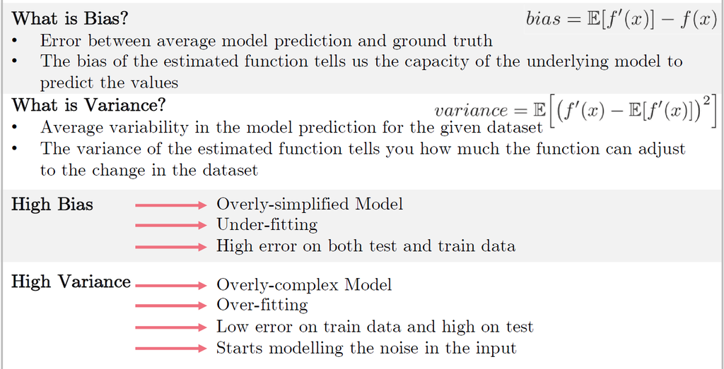

Source: https://www.cheatsheets.aqeel-anwar.com

# The bias-variance trade-off

It is possible to show that the expected test MSE, for a given value $x_0$, can always be decomposed into the sum of three fundamental quantities;

- the variance of $\widehat{f}(x_0)$
- the squared bias of $\widehat{f}(x_0)$
- the variance of the error terms, $\epsilon$

$E(y_0 - \widehat{f}(x_0))^2 = Var(\widehat{f}(x_0)) + [Bias(\widehat{f}(x_0))^2] + Var(\epsilon)$

Here, $E(y_0 - \widehat{f}(x_0))^2$ stands for the expected test MSE at $x_0$. The overall expected test MSE can be computed by averaging $E(y_0 -\widehat{f}(x_0))^2$ over all possible values of $x_0$ in the test set, $\sum E(y_n - \widehat{f}(x_n))^2 / n_{test}$

# The bias-variance trade-off

In order to minimize the expected test error, we need to select a statistical learning method that simultaneously achieves low variance and low bias. Besides, the expected test MSE can never lie below $Var(\epsilon)$, the irreducible error from !

- If a method has high variance then small changes in the training data can result in large changes in $\widehat{f}(.)$. In general, more flexible statistical methods have higher variance.
- Generally, more flexible methods result in less bias. As a general rule, as we use more flexible methods, the variance will increase and the bias will decrease
- Increasing bias (not always) reduces variance and vice-versa. Compromise between bias and variance.
- The best model is where the error is reduced. Good test set performance of a statistical learning method requires low variance as well as low squared bias.

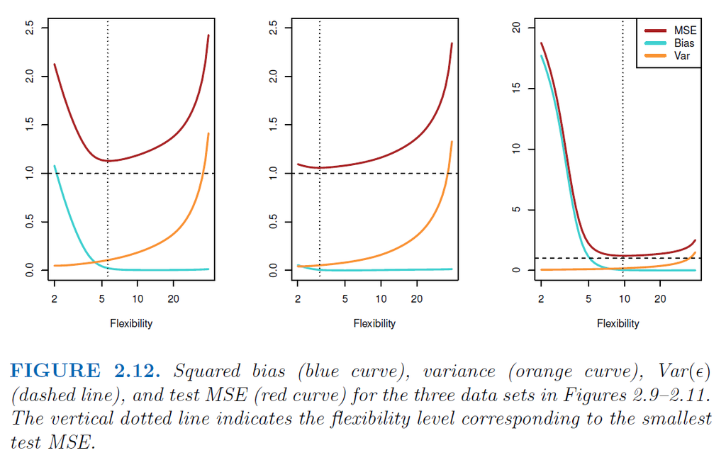

Source: FIGURE 2.12 (ISLR book, page 36)

# Hands on session in R

# Basic Commands

```r
x <- c(1, 3, 2, 5)
x
length(x)

y <- c(5, 6, 7, 5)

x + y

ls()
rm(x, y)
?matrix

matrix(c(1, 2, 3, 4), 2, 2, byrow = TRUE)

sqrt(x)
x^2
```

[output not shown]

# Basic Commands

[output not shown]

```
##  [1] -1.1439763145  1.3421293656  2.1853904757  0.5363925179  0.0631929665
##  [6]  0.5022344825 -0.0004167247  0.5658198405 -0.5725226890 -1.1102250073
## [11] -0.0486871234 -0.6956562176  0.8289174803  0.2066528551 -0.2356745091
## [16] -0.5563104914 -0.3647543571  0.8623550343 -0.6307715354  0.3136021252
## [21] -0.9314953177  0.8238676185  0.5233707021  0.7069214120  0.4202043256
## [26] -0.2690521547 -1.5103172999 -0.6902124766 -0.1434719524 -1.0135274099
## [31]  1.5732737361  0.0127465055  0.8726470499  0.4220661905 -0.0188157917
## [36]  2.6157489689 -0.6931401748 -0.2663217810 -0.7206364412  1.3677342065
## [41]  0.2640073322  0.6321868074 -1.3306509858  0.0268888182  1.0406363208
## [46]  1.3120237985 -0.0300020767 -0.2500257125  0.0234144857  1.6598706557
```

```
## [1] 50.16641
```

```
## [1] 1.025455
```

```
## [1] 1.012647
```

# Indexing Data

[output not shown]

```
## [1] 4 4
```

```
## [1] 10
```

```
##      [,1] [,2]
## [1,]    5   13
## [2,]    7   15
```

```
##      [,1] [,2] [,3]
## [1,]    5    9   13
## [2,]    6   10   14
## [3,]    7   11   15
```

```
##      [,1] [,2] [,3] [,4]
## [1,]    1    5    9   13
## [2,]    2    6   10   14
```

```
##      [,1] [,2] [,3] [,4]
## [1,]    2    6   10   14
## [2,]    4    8   12   16
```

```
## [1] 6 8
```

# Loading Data

```r
Auto <- read.table("Auto.data")
View(Auto)
head(Auto)

Auto <- na.omit(Auto)

names(Auto)
```